# Inflation forecasting with a RNN

```python
iter_output = pd.DataFrame(np.concatenate(results)) #build data frame with results
iter_output.columns = ['m1', 'm2', 'm3', 'm4', 'm5', 'm6', 'm7', 'm8', 'm9', 'm10', 'm11', 'm12']
iter_output
```

|  | m1 | m2 | m3 | m4 | m5 | m6 | m7 | m8 | m9 | m10 | m11 | m12 |
| --- | --- | --- | --- | --- | --- | --- | --- | --- | --- | --- | --- | --- |
| 0 | 0.023203 | 0.021150 | 0.020166 | 0.021899 | 0.019284 | 0.022859 | 0.022299 | 0.021461 | 0.022327 | 0.023947 | 0.024840 | 0.019347 |
| 1 | 0.023271 | 0.022187 | 0.023944 | 0.019815 | 0.022034 | 0.021243 | 0.020847 | 0.020298 | 0.023482 | 0.021154 | 0.017624 | 0.022850 |
| 2 | 0.026894 | 0.020375 | 0.020693 | 0.020446 | 0.021130 | 0.024112 | 0.020904 | 0.023189 | 0.020531 | 0.018882 | 0.022433 | 0.017473 |
| 3 | 0.023403 | 0.023942 | 0.024903 | 0.017795 | 0.020497 | 0.020382 | 0.020662 | 0.026451 | 0.024486 | 0.023249 | 0.021909 | 0.025810 |
| 4 | 0.020224 | 0.016488 | 0.024455 | 0.023496 | 0.018550 | 0.022045 | 0.018314 | 0.017655 | 0.020753 | 0.022343 | 0.020315 | 0.019152 |
| 5 | 0.017648 | 0.021075 | 0.016918 | 0.020788 | 0.022300 | 0.022131 | 0.022264 | 0.020281 | 0.019629 | 0.018918 | 0.019918 | 0.021677 |
| 6 | 0.023208 | 0.023061 | 0.025047 | 0.020469 | 0.020890 | 0.022781 | 0.019400 | 0.020546 | 0.022611 | 0.021155 | 0.019139 | 0.021833 |
| 7 | 0.021313 | 0.020860 | 0.023318 | 0.018163 | 0.021456 | 0.022133 | 0.021298 | 0.024626 | 0.020517 | 0.021457 | 0.020397 | 0.020037 |
| 8 | 0.021237 | 0.019895 | 0.017817 | 0.022396 | 0.022140 | 0.017883 | 0.025201 | 0.019838 | 0.024923 | 0.022080 | 0.019767 | 0.022621 |
| 9 | 0.018425 | 0.019087 | 0.022425 | 0.021221 | 0.020999 | 0.024445 | 0.021479 | 0.021857 | 0.018499 | 0.020312 | 0.021318 | 0.023100 |
| 10 | 0.023979 | 0.020495 | 0.017319 | 0.021736 | 0.021862 | 0.022045 | 0.021736 | 0.023541 | 0.020465 | 0.023676 | 0.021533 | 0.018245 |
| 11 | 0.023390 | 0.023474 | 0.025633 | 0.025424 | 0.024027 | 0.020680 | 0.023835 | 0.022151 | 0.024189 | 0.017808 | 0.023200 | 0.021927 |
| 12 | 0.023689 | 0.020646 | 0.019978 | 0.019014 | 0.019423 | 0.019737 | 0.022539 | 0.021747 | 0.024223 | 0.023188 | 0.022402 | 0.021224 |
| 13 | 0.021080 | 0.022573 | 0.021561 | 0.021396 | 0.020266 | 0.023668 | 0.021175 | 0.020309 | 0.020272 | 0.023153 | 0.022016 | 0.025321 |
| 14 | 0.022079 | 0.020506 | 0.019224 | 0.015039 | 0.022801 | 0.022992 | 0.023228 | 0.018465 | 0.023827 | 0.019629 | 0.021685 | 0.021649 |
| 15 | 0.022777 | 0.022662 | 0.021927 | 0.020658 | 0.018906 | 0.018556 | 0.025515 | 0.021159 | 0.024916 | 0.022709 | 0.019941 | 0.018440 |
| 16 | 0.022568 | 0.022909 | 0.020782 | 0.025543 | 0.023525 | 0.021391 | 0.020775 | 0.017506 | 0.021859 | 0.022370 | 0.020282 | 0.021156 |
| 17 | 0.020311 | 0.020937 | 0.021461 | 0.020475 | 0.020568 | 0.023515 | 0.021842 | 0.018999 | 0.023694 | 0.020207 | 0.020395 | 0.019723 |
| 18 | 0.020349 | 0.022396 | 0.022498 | 0.022780 | 0.018139 | 0.022302 | 0.024270 | 0.020286 | 0.021372 | 0.019423 | 0.021505 | 0.020364 |
| 19 | 0.018933 | 0.019886 | 0.020130 | 0.022530 | 0.016983 | 0.022612 | 0.022211 | 0.018742 | 0.017747 | 0.021191 | 0.019443 | 0.022238 |
| 20 | 0.019001 | 0.022784 | 0.022894 | 0.024951 | 0.021742 | 0.023030 | 0.022183 | 0.020322 | 0.020338 | 0.021672 | 0.023497 | 0.019661 |
| 21 | 0.019491 | 0.020848 | 0.025818 | 0.022776 | 0.021234 | 0.025389 | 0.021012 | 0.021180 | 0.018669 | 0.018881 | 0.020963 | 0.018418 |
| 22 | 0.024057 | 0.021868 | 0.027044 | 0.019343 | 0.023556 | 0.025229 | 0.023274 | 0.021292 | 0.021325 | 0.022482 | 0.020665 | 0.020811 |
| 23 | 0.020036 | 0.019119 | 0.020188 | 0.019690 | 0.021995 | 0.020375 | 0.021630 | 0.020449 | 0.019835 | 0.020537 | 0.022223 | 0.018945 |
| 24 | 0.019040 | 0.019562 | 0.020985 | 0.020931 | 0.021775 | 0.019702 | 0.019764 | 0.021036 | 0.019018 | 0.024926 | 0.020829 | 0.024367 |
| 25 | 0.022794 | 0.022379 | 0.021680 | 0.023529 | 0.020990 | 0.019496 | 0.021105 | 0.020709 | 0.022801 | 0.019532 | 0.019709 | 0.023577 |
| 26 | 0.020285 | 0.027724 | 0.020608 | 0.023158 | 0.026366 | 0.021854 | 0.023758 | 0.027723 | 0.022675 | 0.020058 | 0.022545 | 0.021610 |
| 27 | 0.022437 | 0.019916 | 0.023433 | 0.025548 | 0.020996 | 0.019100 | 0.018267 | 0.022867 | 0.016751 | 0.024871 | 0.021450 | 0.015480 |
| 28 | 0.020293 | 0.023928 | 0.019363 | 0.021610 | 0.019431 | 0.019976 | 0.020384 | 0.023079 | 0.022013 | 0.022067 | 0.020692 | 0.021305 |
| 29 | 0.019522 | 0.018541 | 0.019885 | 0.018600 | 0.019800 | 0.023167 | 0.017863 | 0.020423 | 0.017278 | 0.020753 | 0.019078 | 0.022807 |
| 30 | 0.021192 | 0.017252 | 0.020333 | 0.022349 | 0.021943 | 0.023915 | 0.019398 | 0.020408 | 0.021807 | 0.019519 | 0.021156 | 0.020007 |
| 31 | 0.018166 | 0.018289 | 0.019041 | 0.017925 | 0.021256 | 0.016991 | 0.023224 | 0.020373 | 0.020072 | 0.018946 | 0.022798 | 0.022186 |
| 32 | 0.019446 | 0.017852 | 0.022448 | 0.020398 | 0.017292 | 0.017874 | 0.019576 | 0.021899 | 0.023146 | 0.022149 | 0.019367 | 0.019875 |
| 33 | 0.019128 | 0.024011 | 0.021371 | 0.021562 | 0.021920 | 0.023562 | 0.022962 | 0.021666 | 0.023211 | 0.020680 | 0.023272 | 0.022258 |
| 34 | 0.021545 | 0.020810 | 0.021187 | 0.021852 | 0.021899 | 0.023752 | 0.022451 | 0.021269 | 0.020883 | 0.023315 | 0.022395 | 0.020296 |
| 35 | 0.020118 | 0.018981 | 0.021951 | 0.019948 | 0.018863 | 0.020140 | 0.019611 | 0.020063 | 0.021647 | 0.021192 | 0.019688 | 0.020449 |
| 36 | 0.021468 | 0.020573 | 0.020416 | 0.021268 | 0.021242 | 0.021178 | 0.019643 | 0.021132 | 0.024261 | 0.021873 | 0.022618 | 0.019384 |
| 37 | 0.019847 | 0.020419 | 0.021255 | 0.022690 | 0.021942 | 0.021703 | 0.019268 | 0.020872 | 0.023849 | 0.020947 | 0.020591 | 0.019811 |
| 38 | 0.022043 | 0.024299 | 0.021015 | 0.019837 | 0.020433 | 0.021741 | 0.023131 | 0.022884 | 0.020758 | 0.021166 | 0.021411 | 0.022832 |
| 39 | 0.022638 | 0.023917 | 0.020163 | 0.022314 | 0.022207 | 0.023669 | 0.024494 | 0.023221 | 0.023206 | 0.025918 | 0.025309 | 0.021895 |
| 40 | 0.020748 | 0.020263 | 0.020394 | 0.021206 | 0.020608 | 0.020506 | 0.020524 | 0.018689 | 0.021376 | 0.019513 | 0.018871 | 0.021095 |
| 41 | 0.023978 | 0.023036 | 0.019823 | 0.024912 | 0.019670 | 0.020216 | 0.022790 | 0.021361 | 0.021981 | 0.023124 | 0.021465 | 0.019593 |
| 42 | 0.023578 | 0.023141 | 0.021384 | 0.020520 | 0.021623 | 0.019255 | 0.022268 | 0.023510 | 0.021962 | 0.022417 | 0.019373 | 0.020622 |
| 43 | 0.024682 | 0.027125 | 0.025173 | 0.020495 | 0.022719 | 0.021323 | 0.023622 | 0.021658 | 0.025829 | 0.019369 | 0.020379 | 0.021184 |
| 44 | 0.019757 | 0.021436 | 0.019400 | 0.023245 | 0.020778 | 0.022605 | 0.021005 | 0.024061 | 0.020636 | 0.021311 | 0.021209 | 0.020456 |
| 45 | 0.020914 | 0.021707 | 0.021806 | 0.019415 | 0.020581 | 0.023300 | 0.023920 | 0.023694 | 0.020862 | 0.021470 | 0.020955 | 0.021726 |
| 46 | 0.020041 | 0.022929 | 0.021945 | 0.024956 | 0.024218 | 0.023013 | 0.017748 | 0.021896 | 0.021251 | 0.023445 | 0.025325 | 0.021383 |
| 47 | 0.018842 | 0.022615 | 0.019940 | 0.019274 | 0.019773 | 0.021318 | 0.019973 | 0.023576 | 0.021539 | 0.023805 | 0.020455 | 0.020477 |
| 48 | 0.021910 | 0.023055 | 0.019358 | 0.025116 | 0.018306 | 0.018817 | 0.022141 | 0.019902 | 0.023006 | 0.019524 | 0.022304 | 0.019412 |
| 49 | 0.020019 | 0.015698 | 0.022231 | 0.020393 | 0.022798 | 0.023690 | 0.023065 | 0.020236 | 0.019679 | 0.023852 | 0.025454 | 0.019420 |

Now we compute the mean and mean squared error to make a forecast with a confidence interval. Lets start with the mean.

```python
mean_forecast = pd.DataFrame([iter_output['m1'].mean(),
                iter_output['m2'].mean(),
                iter_output['m3'].mean(),
                iter_output['m4'].mean(),
                iter_output['m5'].mean(),
                iter_output['m6'].mean(),
                iter_output['m7'].mean(),
                iter_output['m8'].mean(),
                iter_output['m9'].mean(),
                iter_output['m10'].mean(),
                iter_output['m11'].mean(),
                iter_output['m12'].mean()], index=pd.date_range('02/01/2019',periods=12,freq='M')) #mean dataframe
mean_forecast.columns = ['predicted']
mean_forecast
```

|  | predicted |
| --- | --- |
| 2019-02-28 | 0.021300 |
| 2019-03-31 | 0.021374 |
| 2019-04-30 | 0.021455 |
| 2019-05-31 | 0.021418 |
| 2019-06-30 | 0.021075 |
| 2019-07-31 | 0.021668 |
| 2019-08-31 | 0.021597 |
| 2019-09-30 | 0.021411 |
| 2019-10-31 | 0.021640 |
| 2019-11-30 | 0.021523 |
| 2019-12-31 | 0.021322 |
| 2020-01-31 | 0.020911 |

Now lets estimate the standard deviation.

```python
se_forecast = pd.DataFrame([iter_output['m1'].std(),
                iter_output['m2'].std(),
                iter_output['m3'].std(),
                iter_output['m4'].std(),
                iter_output['m5'].std(),
                iter_output['m6'].std(),
                iter_output['m7'].std(),
                iter_output['m8'].std(),
                iter_output['m9'].std(),
                iter_output['m10'].std(),
                iter_output['m11'].std(),
                iter_output['m12'].std()], index=pd.date_range('02/01/2019',periods=12,freq='M')) #se daaframe
se_forecast.columns = ['predicted']
se_forecast
```

|  | predicted |
| --- | --- |
| 2019-02-28 | 0.001972 |
| 2019-03-31 | 0.002368 |
| 2019-04-30 | 0.002177 |
| 2019-05-31 | 0.002246 |
| 2019-06-30 | 0.001793 |
| 2019-07-31 | 0.001976 |
| 2019-08-31 | 0.001879 |
| 2019-09-30 | 0.001994 |
| 2019-10-31 | 0.002054 |
| 2019-11-30 | 0.001836 |
| 2019-12-31 | 0.001719 |
| 2020-01-31 | 0.001912 |

Now we compute a 95% confidence interval assumming a normal distribution by adding and subtracting two standard deviations from the mean.

```python
upper_bound = mean_forecast + 2*se_forecast
lower_bound = mean_forecast - 2*se_forecast
```

```
<function matplotlib.pyplot.show(*args, **kw)>
```

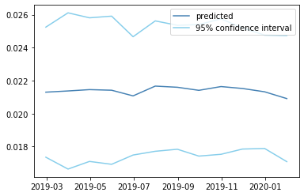

```python
plt.plot(mean_forecast, label = 'predicted', color = 'SteelBlue')
plt.plot(upper_bound, label = '95% confidence interval', color = 'SkyBlue')
plt.plot(lower_bound, color = 'SkyBlue')
plt.legend()
plt.show
```

```python
observed = pd.DataFrame(pd.read_csv(r'C:\Users\aasg\OneDrive\Escritorio\Tilburg University\Thesis\R_Files\dfUS.csv',
                       sep = ',',
                       skiprows = 289,
                       usecols = [2]))
observed.columns = ['observed']
observed.index = pd.date_range('02/01/2019',periods=12,freq='M')
observed
```

|  | observed |
| --- | --- |
| 2019-02-28 | 0.020848 |
| 2019-03-31 | 0.020471 |
| 2019-04-30 | 0.020851 |
| 2019-05-31 | 0.020003 |
| 2019-06-30 | 0.021377 |
| 2019-07-31 | 0.022043 |
| 2019-08-31 | 0.023696 |
| 2019-09-30 | 0.023495 |
| 2019-10-31 | 0.023143 |
| 2019-11-30 | 0.023173 |
| 2019-12-31 | 0.022486 |
| 2020-01-31 | 0.022681 |

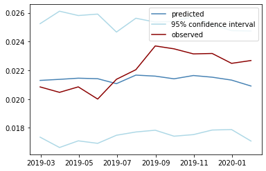

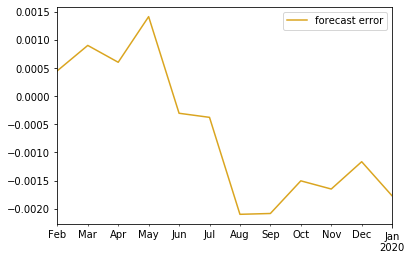

```
(forecast error   -0.000631
 dtype: float64, predicted    0.021391
 dtype: float64)
```

```python
plt.plot(mean_forecast, label = 'predicted', color = 'SteelBlue')
plt.plot(upper_bound, label = '95% confidence interval', color = 'lightblue')
plt.plot(lower_bound, color = 'lightblue')
plt.plot(observed, label = 'observed', color = 'DarkRed')
plt.legend()
plt.show

model_error = array(mean_forecast) - array(observed)
model_error = pd.DataFrame(model_error, index=pd.date_range('02/01/2019',periods=12,freq='M'))
model_error.columns = ['forecast error']

model_error.plot(color = 'goldenrod')
plt.show()

model_error.mean(), mean_forecast.mean()
```

```python
mean_forecast.to_csv(r'C:\Users\aasg\OneDrive\Escritorio\Tilburg University\Thesis\Python_Files\nn_keras_predicted_us.csv')
```

```python
model_error.to_csv(r'C:\Users\aasg\OneDrive\Escritorio\Tilburg University\Thesis\Python_Files\nn_keras_error_us.csv')
```

The model actualy makes a great prediction for US inflation, with errors that range from -0.0025 to 0.0015, in other words, 40 bps. On average, the model underestimates inflation with an error of 6 bps. Finally, the average forecasted inflation rate is in line with the FED's target inflation.

## Neural Network for the EA

```python
#training
#inputs raw
in_inf = array(dataEA.loc['1999-01-01':'2015-01-01', ['infEA']])
in_int = array(dataEA.loc['1999-01-01':'2015-01-01', ['intrateEA']])
in_M2  = array(dataEA.loc['1999-01-01':'2015-01-01', ['M2EA']])
in_gdp = array(dataEA.loc['1999-01-01':'2015-01-01', ['OutputGapEA']])
in_u   = array(dataEA.loc['1999-01-01':'2015-01-01', ['urateEA']])
in_rer = array(dataEA.loc['1999-01-01':'2015-01-01', ['REREA']])


#output raw
out_inf = array(dataEA.loc['1999-01-01':'2015-01-01', ['infEA']])

#reshape to [rows, columns]
in_inf = in_inf.reshape((len(in_inf), 1))
in_int = in_int.reshape((len(in_int), 1))
in_M2  = in_M2.reshape((len(in_M2), 1))
in_gdp = in_gdp.reshape((len(in_gdp), 1))
in_u   = in_u.reshape((len(in_u), 1))
in_rer = in_rer.reshape((len(in_rer), 1))


out_inf = out_inf.reshape((len(out_inf), 1))


#validation
#inputs raw
valin_inf = array(dataEA.loc['2015-01-01':'2019-01-01', ['infEA']])
valin_int = array(dataEA.loc['2015-01-01':'2019-01-01', ['intrateEA']])
valin_M2  = array(dataEA.loc['2015-01-01':'2019-01-01', ['M2EA']])
valin_gdp = array(dataEA.loc['2015-01-01':'2019-01-01', ['OutputGapEA']])
valin_u   = array(dataEA.loc['2015-01-01':'2019-01-01', ['urateEA']])
valin_rer = array(dataEA.loc['2015-01-01':'2019-01-01', ['REREA']])


#output raw
valout_inf = array(dataEA.loc['2015-01-01':'2019-01-01', ['infEA']])

#reshape to [rows, columns]
valin_inf = valin_inf.reshape((len(valin_inf), 1))
valin_int = valin_int.reshape((len(valin_int), 1))
valin_M2  = valin_M2.reshape((len(valin_M2), 1))
valin_gdp = valin_gdp.reshape((len(valin_gdp), 1))
valin_u   = valin_u.reshape((len(valin_u), 1))
valin_rer = valin_rer.reshape((len(valin_rer), 1))


valout_inf = valout_inf.reshape((len(valout_inf), 1))

#out-of-sample inputs
x_inf = array(dataEA.loc['2018-02-01':'2019-01-01', ['infEA']])
x_int = array(dataEA.loc['2018-02-01':'2019-01-01', ['intrateEA']])
x_M2  = array(dataEA.loc['2018-02-01':'2019-01-01', ['M2EA']])
x_gdp = array(dataEA.loc['2018-02-01':'2019-01-01', ['OutputGapEA']])
x_u   = array(dataEA.loc['2018-02-01':'2019-01-01', ['urateEA']])
x_rer = array(dataEA.loc['2018-02-01':'2019-01-01', ['REREA']])

#stack columns horizontally
dataset = hstack((in_inf, in_int, in_M2, in_gdp, in_u, in_rer, out_inf))
valset = hstack((valin_inf, valin_int, valin_M2, valin_gdp, valin_u, valin_rer, valout_inf))

#timesteps
n_steps_in, n_steps_out = 12, 12 #use 12 observations to predict next 12

X, y = split_sequences(dataset, n_steps_in, n_steps_out)
print(X.shape, y.shape) #shape of input and output
valX, valy = split_sequences(valset, n_steps_in, n_steps_out)
```

```
(171, 12, 6) (171, 12)
```

Now we train a single network.

```
<function matplotlib.pyplot.show(*args, **kw)>
```

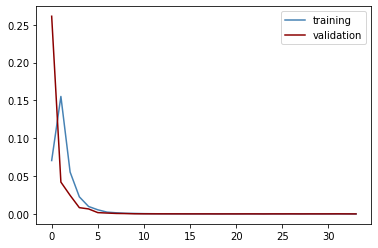

```python
n_features = X.shape[2]

#model

model = Sequential()
model.add(LSTM(100,
               activation = 'tanh',
               return_sequences = True,
               input_shape = (n_steps_in, n_features)))
model.add(LSTM(100,
               dropout = 0.7,
               recurrent_dropout = 0.7,
              activation = 'tanh'))
model.add(Dense(50, activation = 'tanh'))
model.add(Dense(25, activation = 'tanh'))
model.add(Dense(n_steps_out))

#compile model

model.compile(optimizer = keras.optimizers.Adam(learning_rate = 0.04),
              loss = 'mse')


es = EarlyStopping(monitor = 'val_loss',
                  mode = 'min',
                  min_delta = 0.01,
                  patience = 30,
                  verbose = 0)

#fit
fit = model.fit(X,
          y,
          validation_data = (valX, valy),
          epochs = 500,
          verbose = 0,
          callbacks = [es])

#check for overfitting
plt.plot(fit.history['loss'], label = 'training', color = 'SteelBlue')
plt.plot(fit.history['val_loss'], label = 'validation', color = 'DarkRed')
plt.legend()
plt.show
```

Once there are no signs of overfitting we may proceed to building the shape of our out-of-sample inputs and produce 50 out-of-sample predictions to generate a forecast. Just to be sure, lets make a single forecast to check everuthing is in order.

```python
#shape out-of-sample inputs
x_input = array([x_inf,
                 x_int,
                 x_M2,
                 x_gdp,
                 x_u,
                 x_rer])
x_input = x_input.reshape((1, n_steps_in, n_features))

yhat = model.predict(x_input, verbose = 0)
print(yhat)
```

```
[[0.01904961 0.01501111 0.01663224 0.01647729 0.009891   0.01270734
  0.01032338 0.02253567 0.01169541 0.0141917  0.01483737 0.01998207]]
```

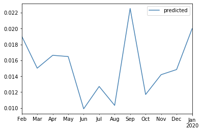

```python
predicted = pd.DataFrame(yhat.T, index=pd.date_range('02/01/2019',periods=12,freq='M'))
predicted.columns = ['predicted']

predicted.plot(color = 'SteelBlue')
plt.show()
```

Everything seems to be working fine. I'll produce 50 different forecasts with a for loop.

```python
n = 50
results = []
for i in range(0, n):
    model = Sequential()
    model.add(LSTM(100,
               activation = 'tanh',
               return_sequences = True,
               input_shape = (n_steps_in, n_features)))
    model.add(LSTM(100,
               dropout = 0.7,
               recurrent_dropout = 0.7,
              activation = 'tanh'))
    model.add(Dense(50, activation = 'tanh'))
    model.add(Dense(25, activation = 'tanh'))
    model.add(Dense(n_steps_out))

    model.compile(optimizer = keras.optimizers.Adam(learning_rate = 0.04),
              loss = 'mse')

    fit = model.fit(X,
          y,
          validation_data = (valX, valy),
          epochs = 500,
          verbose = 0,
          callbacks = [es])

    yhat = model.predict(x_input, verbose = 0)
    results.append((yhat))
```

Now we have to reshape our results in order to compute the mean and standard deviation.

```python
iter_output = pd.DataFrame(np.concatenate(results)) #build data frame with results
iter_output.columns = ['m1', 'm2', 'm3', 'm4', 'm5', 'm6', 'm7', 'm8', 'm9', 'm10', 'm11', 'm12']

#mean
mean_forecast = pd.DataFrame([iter_output['m1'].mean(),
                iter_output['m2'].mean(),
                iter_output['m3'].mean(),
                iter_output['m4'].mean(),
                iter_output['m5'].mean(),
                iter_output['m6'].mean(),
                iter_output['m7'].mean(),
                iter_output['m8'].mean(),
                iter_output['m9'].mean(),
                iter_output['m10'].mean(),
                iter_output['m11'].mean(),
                iter_output['m12'].mean()], index=pd.date_range('02/01/2019',periods=12,freq='M')) #mean dataframe
mean_forecast.columns = ['predicted']

#standard deviation
se_forecast = pd.DataFrame([iter_output['m1'].std(),
                iter_output['m2'].std(),
                iter_output['m3'].std(),
                iter_output['m4'].std(),
                iter_output['m5'].std(),
                iter_output['m6'].std(),
                iter_output['m7'].std(),
                iter_output['m8'].std(),
                iter_output['m9'].std(),
                iter_output['m10'].std(),
                iter_output['m11'].std(),
                iter_output['m12'].std()], index=pd.date_range('02/01/2019',periods=12,freq='M')) #se daaframe
se_forecast.columns = ['predicted']
```

Once calculated, we can use the mean and standar deviation to build the upper and lower bound of our forecast's confidence interval. Assuming a normal distribution and following the 68, 95, 99.7 rule, I add and subtract two standard deviations to the mean in order to get a 95% confidence interval.

```python
upper_bound = mean_forecast + 2*se_forecast
lower_bound = mean_forecast - 2*se_forecast
```

Now we can plot our forecast.

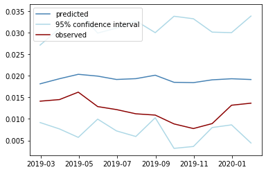

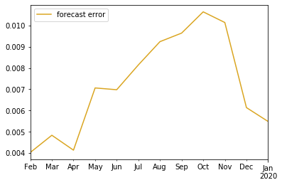

```
(forecast error    0.007206
 dtype: float64, predicted    0.019224
 dtype: float64)
```

```python
#plotting
observed = pd.DataFrame(pd.read_csv(r'C:\Users\aasg\OneDrive\Escritorio\Tilburg University\Thesis\R_Files\dfEA.csv',
                       sep = ',',
                       skiprows = len(dataEA) - 12,
                       usecols = [2]))
observed.columns = ['observed']
observed.index = pd.date_range('02/01/2019',periods=12,freq='M')

plt.plot(mean_forecast, label = 'predicted', color = 'SteelBlue')
plt.plot(upper_bound, label = '95% confidence interval', color = 'lightblue')
plt.plot(lower_bound, color = 'lightblue')
plt.plot(observed, label = 'observed', color = 'DarkRed')
plt.legend()
plt.show

model_error = array(mean_forecast) - array(observed)
model_error = pd.DataFrame(model_error, index=pd.date_range('02/01/2019',periods=12,freq='M'))
model_error.columns = ['forecast error']

model_error.plot(color = 'goldenrod')
plt.show()

model_error.mean(), mean_forecast.mean()
```

```python
mean_forecast.to_csv(r'C:\Users\aasg\OneDrive\Escritorio\Tilburg University\Thesis\Python_Files\nn_keras_predicted_ea.csv')
model_error.to_csv(r'C:\Users\aasg\OneDrive\Escritorio\Tilburg University\Thesis\Python_Files\nn_keras_error_ea.csv')
```

In the case of the EA, the network manages to predict inflation within its 95% confidence interval, overestimating inflation by 72 bps on average. Additionally, average inflation forecasted is in line with ECB's inflation target.

## Neural Network for the NL

Since the code is explained in the EA section, from now on I will focus on code cells.

```python
#training
#inputs raw
in_inf = array(dataNL.loc['1999-01-01':'2015-01-01', ['infNL']])
in_int = array(dataNL.loc['1999-01-01':'2015-01-01', ['intrateNL']])
in_M2  = array(dataNL.loc['1999-01-01':'2015-01-01', ['M2NL']])
in_gdp = array(dataNL.loc['1999-01-01':'2015-01-01', ['OutputGapNL']])
in_u   = array(dataNL.loc['1999-01-01':'2015-01-01', ['urateNL']])
in_rer = array(dataNL.loc['1999-01-01':'2015-01-01', ['RERNL']])
in_rw  = array(dataNL.loc['1999-01-01':'2015-01-01', ['realWNL']])

#output raw
out_inf = array(dataNL.loc['1999-01-01':'2015-01-01', ['infNL']])

#reshape to [rows, columns]
in_inf = in_inf.reshape((len(in_inf), 1))
in_int = in_int.reshape((len(in_int), 1))
in_M2  = in_M2.reshape((len(in_M2), 1))
in_gdp = in_gdp.reshape((len(in_gdp), 1))
in_u   = in_u.reshape((len(in_u), 1))
in_rer = in_rer.reshape((len(in_rer), 1))
in_rw = in_rw.reshape((len(in_rw), 1))

out_inf = out_inf.reshape((len(out_inf), 1))


#validation
#inputs raw
valin_inf = array(dataNL.loc['2015-01-01':'2019-01-01', ['infNL']])
valin_int = array(dataNL.loc['2015-01-01':'2019-01-01', ['intrateNL']])
valin_M2  = array(dataNL.loc['2015-01-01':'2019-01-01', ['M2NL']])
valin_gdp = array(dataNL.loc['2015-01-01':'2019-01-01', ['OutputGapNL']])
valin_u   = array(dataNL.loc['2015-01-01':'2019-01-01', ['urateNL']])
valin_rer = array(dataNL.loc['2015-01-01':'2019-01-01', ['RERNL']])
valin_rw  = array(dataNL.loc['2015-01-01':'2019-01-01', ['realWNL']])

#output raw
valout_inf = array(dataNL.loc['2015-01-01':'2019-01-01', ['infNL']])

#reshape to [rows, columns]
valin_inf = valin_inf.reshape((len(valin_inf), 1))
valin_int = valin_int.reshape((len(valin_int), 1))
valin_M2  = valin_M2.reshape((len(valin_M2), 1))
valin_gdp = valin_gdp.reshape((len(valin_gdp), 1))
valin_u   = valin_u.reshape((len(valin_u), 1))
valin_rer = valin_rer.reshape((len(valin_rer), 1))


valout_inf = valout_inf.reshape((len(valout_inf), 1))

#out-of-sample inputs
x_inf = array(dataNL.loc['2018-02-01':'2019-01-01', ['infNL']])
x_int = array(dataNL.loc['2018-02-01':'2019-01-01', ['intrateNL']])
x_M2  = array(dataNL.loc['2018-02-01':'2019-01-01', ['M2NL']])
x_gdp = array(dataNL.loc['2018-02-01':'2019-01-01', ['OutputGapNL']])
x_u   = array(dataNL.loc['2018-02-01':'2019-01-01', ['urateNL']])
x_rer = array(dataNL.loc['2018-02-01':'2019-01-01', ['RERNL']])
x_rwb = array(dataNL.loc['2018-02-01':'2019-01-01', ['realWNL']])

#stack columns horizontally
dataset = hstack((in_inf, in_int, in_M2, in_gdp, in_u, in_rer, in_rw, out_inf))
valset = hstack((valin_inf, valin_int, valin_M2, valin_gdp, valin_u, valin_rer, valin_rw, valout_inf))

#timesteps
n_steps_in, n_steps_out = 12, 12 #use 12 observations to predict next 12

X, y = split_sequences(dataset, n_steps_in, n_steps_out)
print(X.shape, y.shape) #shape of input and output
valX, valy = split_sequences(valset, n_steps_in, n_steps_out)
```

```
(171, 12, 7) (171, 12)
```

```
<function matplotlib.pyplot.show(*args, **kw)>
```

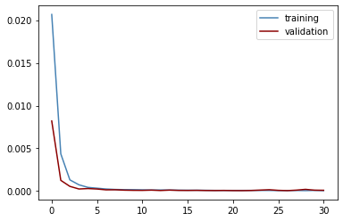

```python
n_features = X.shape[2]

#model

model = Sequential()
model.add(LSTM(100,
               activation = 'tanh',
               return_sequences = True,
               input_shape = (n_steps_in, n_features)))
model.add(LSTM(100,
               dropout = 0.3,
               recurrent_dropout = 0.3,
              activation = 'tanh'))
model.add(Dense(50, activation = 'tanh'))
model.add(Dense(25, activation = 'tanh'))
model.add(Dense(n_steps_out))

#compile model

model.compile(optimizer = keras.optimizers.Adam(learning_rate = 0.02),
              loss = 'mse')


es = EarlyStopping(monitor = 'val_loss',
                  mode = 'min',
                  min_delta = 0.01,
                  patience = 30,
                  verbose = 0)

#fit
fit = model.fit(X,
          y,
          validation_data = (valX, valy),
          epochs = 500,
          verbose = 0,
          callbacks = [es])

#check for overfitting
plt.plot(fit.history['loss'], label = 'training', color = 'SteelBlue')
plt.plot(fit.history['val_loss'], label = 'validation', color = 'DarkRed')
plt.legend()
plt.show
```

```
[[0.01482949 0.01709831 0.01156699 0.01498986 0.0088535  0.01377693
  0.01323276 0.01642259 0.0114572  0.0195916  0.01751619 0.01523621]]
```

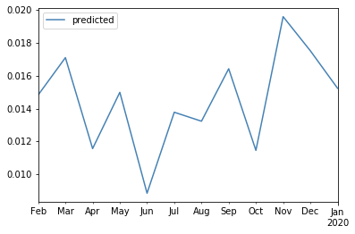

```python
#shape out-of-sample inputs
x_input = array([x_inf,
                 x_int,
                 x_M2,
                 x_gdp,
                 x_u,
                 x_rer,
                 x_rw])
x_input = x_input.reshape((1, n_steps_in, n_features))

yhat = model.predict(x_input, verbose = 0)
print(yhat)

predicted = pd.DataFrame(yhat.T, index=pd.date_range('02/01/2019',periods=12,freq='M'))
predicted.columns = ['predicted']

predicted.plot(color = 'SteelBlue')
plt.show()
```

```python
n = 50
results = []
for i in range(0, n):
    model = Sequential()
    model.add(LSTM(100,
               activation = 'tanh',
               return_sequences = True,
               input_shape = (n_steps_in, n_features)))
    model.add(LSTM(100,
               dropout = 0.3,
               recurrent_dropout = 0.3,
              activation = 'tanh'))
    model.add(Dense(50, activation = 'tanh'))
    model.add(Dense(25, activation = 'tanh'))
    model.add(Dense(n_steps_out))

    model.compile(optimizer = keras.optimizers.Adam(learning_rate = 0.02),
              loss = 'mse')

    fit = model.fit(X,
          y,
          validation_data = (valX, valy),
          epochs = 500,
          verbose = 0,
          callbacks = [es])

    yhat = model.predict(x_input, verbose = 0)
    results.append((yhat))
```

```python
iter_output = pd.DataFrame(np.concatenate(results)) #build data frame with results
iter_output.columns = ['m1', 'm2', 'm3', 'm4', 'm5', 'm6', 'm7', 'm8', 'm9', 'm10', 'm11', 'm12']

#mean
mean_forecast = pd.DataFrame([iter_output['m1'].mean(),
                iter_output['m2'].mean(),
                iter_output['m3'].mean(),
                iter_output['m4'].mean(),
                iter_output['m5'].mean(),
                iter_output['m6'].mean(),
                iter_output['m7'].mean(),
                iter_output['m8'].mean(),
                iter_output['m9'].mean(),
                iter_output['m10'].mean(),
                iter_output['m11'].mean(),
                iter_output['m12'].mean()], index=pd.date_range('02/01/2019',periods=12,freq='M')) #mean dataframe
mean_forecast.columns = ['predicted']

#standard deviation
se_forecast = pd.DataFrame([iter_output['m1'].std(),
                iter_output['m2'].std(),
                iter_output['m3'].std(),
                iter_output['m4'].std(),
                iter_output['m5'].std(),
                iter_output['m6'].std(),
                iter_output['m7'].std(),
                iter_output['m8'].std(),
                iter_output['m9'].std(),
                iter_output['m10'].std(),
                iter_output['m11'].std(),
                iter_output['m12'].std()], index=pd.date_range('02/01/2019',periods=12,freq='M')) #se daaframe
se_forecast.columns = ['predicted']
```

```python
upper_bound = mean_forecast + 2*se_forecast
lower_bound = mean_forecast - 2*se_forecast
```

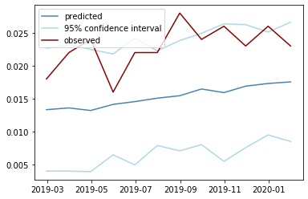

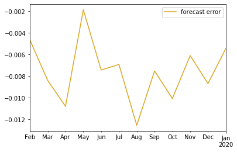

```
(forecast error   -0.007539
 dtype: float64, predicted    0.015295
 dtype: float64)
```

```python
#plotting
observed = pd.DataFrame(pd.read_csv(r'C:\Users\aasg\OneDrive\Escritorio\Tilburg University\Thesis\R_Files\dfNL.csv',
                       sep = ',',
                       skiprows = len(dataNL) - 12,
                       usecols = [2]))
observed.columns = ['observed']
observed.index = pd.date_range('02/01/2019',periods=12,freq='M')

plt.plot(mean_forecast, label = 'predicted', color = 'SteelBlue')
plt.plot(upper_bound, label = '95% confidence interval', color = 'lightblue')
plt.plot(lower_bound, color = 'lightblue')
plt.plot(observed, label = 'observed', color = 'DarkRed')
plt.legend()
plt.show

model_error = array(mean_forecast) - array(observed)
model_error = pd.DataFrame(model_error, index=pd.date_range('02/01/2019',periods=12,freq='M'))
model_error.columns = ['forecast error']

model_error.plot(color = 'goldenrod')
plt.show()

model_error.mean(), mean_forecast.mean()
```

```python
mean_forecast.to_csv(r'C:\Users\aasg\OneDrive\Escritorio\Tilburg University\Thesis\Python_Files\nn_keras_predicted_nl.csv')
model_error.to_csv(r'C:\Users\aasg\OneDrive\Escritorio\Tilburg University\Thesis\Python_Files\nn_keras_error_nl.csv')
```

The network provides a rasonable inflation forecast that is most of the time within the 95% confidence interval. On average, the model underestimates inflation by 75 bps and predicts an infaltion rate consistent with the ECB's target rate of below but close to 2% (if we take into account standard error).

## Neural Network for CL

```python
#training
#inputs raw
in_inf = array(dataCL.loc['1996-01-01':'2015-01-01', ['infCL']])
in_int = array(dataCL.loc['1996-01-01':'2015-01-01', ['intrateCL']])
in_M2  = array(dataCL.loc['1996-01-01':'2015-01-01', ['M2CL']])
in_gdp = array(dataCL.loc['1996-01-01':'2015-01-01', ['OutputGapCL']])
in_u   = array(dataCL.loc['1996-01-01':'2015-01-01', ['urateCL']])
in_rer = array(dataCL.loc['1996-01-01':'2015-01-01', ['RERCL']])
in_rw  = array(dataCL.loc['1996-01-01':'2015-01-01', ['realWCL']])


#output raw
out_inf = array(dataCL.loc['1996-01-01':'2015-01-01', ['infCL']])

#reshape to [rows, columns]
in_inf = in_inf.reshape((len(in_inf), 1))
in_int = in_int.reshape((len(in_int), 1))
in_M2  = in_M2.reshape((len(in_M2), 1))
in_gdp = in_gdp.reshape((len(in_gdp), 1))
in_u   = in_u.reshape((len(in_u), 1))
in_rer = in_rer.reshape((len(in_rer), 1))


out_inf = out_inf.reshape((len(out_inf), 1))


#validation
#inputs raw
valin_inf = array(dataCL.loc['2015-01-01':'2019-01-01', ['infCL']])
valin_int = array(dataCL.loc['2015-01-01':'2019-01-01', ['intrateCL']])
valin_M2  = array(dataCL.loc['2015-01-01':'2019-01-01', ['M2CL']])
valin_gdp = array(dataCL.loc['2015-01-01':'2019-01-01', ['OutputGapCL']])
valin_u   = array(dataCL.loc['2015-01-01':'2019-01-01', ['urateCL']])
valin_rer = array(dataCL.loc['2015-01-01':'2019-01-01', ['RERCL']])
valin_rw  = array(dataCL.loc['2015-01-01':'2019-01-01', ['realWCL']])

#output raw
valout_inf = array(dataCL.loc['2015-01-01':'2019-01-01', ['infCL']])

#reshape to [rows, columns]
valin_inf = valin_inf.reshape((len(valin_inf), 1))
valin_int = valin_int.reshape((len(valin_int), 1))
valin_M2  = valin_M2.reshape((len(valin_M2), 1))
valin_gdp = valin_gdp.reshape((len(valin_gdp), 1))
valin_u   = valin_u.reshape((len(valin_u), 1))
valin_rer = valin_rer.reshape((len(valin_rer), 1))


valout_inf = valout_inf.reshape((len(valout_inf), 1))

#out-of-sample inputs
x_inf = array(dataCL.loc['2018-02-01':'2019-01-01', ['infCL']])
x_int = array(dataCL.loc['2018-02-01':'2019-01-01', ['intrateCL']])
x_M2  = array(dataCL.loc['2018-02-01':'2019-01-01', ['M2CL']])
x_gdp = array(dataCL.loc['2018-02-01':'2019-01-01', ['OutputGapCL']])
x_u   = array(dataCL.loc['2018-02-01':'2019-01-01', ['urateCL']])
x_rer = array(dataCL.loc['2018-02-01':'2019-01-01', ['RERCL']])
x_rw  = array(dataCL.loc['2018-02-01':'2019-01-01', ['realWCL']])

#stack columns horizontally
dataset = hstack((in_inf, in_int, in_M2, in_gdp, in_u, in_rer, in_rw, out_inf))
valset = hstack((valin_inf, valin_int, valin_M2, valin_gdp, valin_u, valin_rer, valin_rw, valout_inf))

#timesteps
n_steps_in, n_steps_out = 12, 12 #use 12 observations to predict next 12

X, y = split_sequences(dataset, n_steps_in, n_steps_out)
print(X.shape, y.shape) #shape of input and output
valX, valy = split_sequences(valset, n_steps_in, n_steps_out)
```

```
(207, 12, 7) (207, 12)
```

```
<function matplotlib.pyplot.show(*args, **kw)>
```

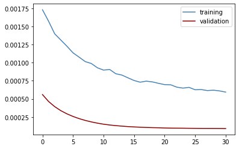

```python
n_features = X.shape[2]

#model

model = Sequential()
model.add(LSTM(100,
               activation = 'tanh',
               return_sequences = True,
               input_shape = (n_steps_in, n_features)))
model.add(LSTM(100,
               dropout = 0.6,
               recurrent_dropout = 0.6,
              activation = 'tanh'))
model.add(Dense(50, activation = 'tanh'))
model.add(Dense(25, activation = 'tanh'))
model.add(Dense(n_steps_out))

#compile model

model.compile(optimizer = keras.optimizers.Adam(learning_rate = 0.000025),
              loss = 'mse')


es = EarlyStopping(monitor = 'val_loss',
                  mode = 'min',
                  min_delta = 0.001,
                  patience = 30,
                  verbose = 0)

#fit
fit = model.fit(X,
          y,
          validation_data = (valX, valy),
          epochs = 500,
          verbose = 0,
          callbacks = [es])

#check for overfitting
plt.plot(fit.history['loss'], label = 'training', color = 'SteelBlue')
plt.plot(fit.history['val_loss'], label = 'validation', color = 'DarkRed')
plt.legend()
plt.show
```

```
[[0.02812429 0.02683605 0.02436033 0.01412169 0.01926202 0.03531358
  0.02211548 0.03017997 0.02673633 0.03045469 0.01749032 0.03179049]]
```

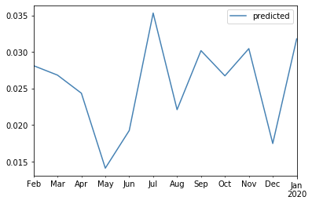

```python
#shape out-of-sample inputs
x_input = array([x_inf,
                 x_int,
                 x_M2,
                 x_gdp,
                 x_u,
                 x_rer,
                 x_rw])
x_input = x_input.reshape((1, n_steps_in, n_features))

yhat = model.predict(x_input, verbose = 0)
print(yhat)

predicted = pd.DataFrame(yhat.T, index=pd.date_range('02/01/2019',periods=12,freq='M'))
predicted.columns = ['predicted']

predicted.plot(color = 'SteelBlue')
plt.show()
```

```python
n = 50
results = []
for i in range(0, n):
    model = Sequential()
    model.add(LSTM(100,
               activation = 'tanh',
               return_sequences = True,
               input_shape = (n_steps_in, n_features)))
    model.add(LSTM(100,
               dropout = 0.6,
               recurrent_dropout = 0.6,
              activation = 'tanh'))
    model.add(Dense(50, activation = 'tanh'))
    model.add(Dense(25, activation = 'tanh'))
    model.add(Dense(n_steps_out))

    model.compile(optimizer = keras.optimizers.Adam(learning_rate = 0.000025),
              loss = 'mse')

    fit = model.fit(X,
          y,
          validation_data = (valX, valy),
          epochs = 500,
          verbose = 0,
          callbacks = [es])

    yhat = model.predict(x_input, verbose = 0)
    results.append((yhat))
```

```python
iter_output = pd.DataFrame(np.concatenate(results)) #build data frame with results
iter_output.columns = ['m1', 'm2', 'm3', 'm4', 'm5', 'm6', 'm7', 'm8', 'm9', 'm10', 'm11', 'm12']

#mean
mean_forecast = pd.DataFrame([iter_output['m1'].mean(),
                iter_output['m2'].mean(),
                iter_output['m3'].mean(),
                iter_output['m4'].mean(),
                iter_output['m5'].mean(),
                iter_output['m6'].mean(),
                iter_output['m7'].mean(),
                iter_output['m8'].mean(),
                iter_output['m9'].mean(),
                iter_output['m10'].mean(),
                iter_output['m11'].mean(),
                iter_output['m12'].mean()], index=pd.date_range('02/01/2019',periods=12,freq='M')) #mean dataframe
mean_forecast.columns = ['predicted']

#standard deviation
se_forecast = pd.DataFrame([iter_output['m1'].std(),
                iter_output['m2'].std(),
                iter_output['m3'].std(),
                iter_output['m4'].std(),
                iter_output['m5'].std(),
                iter_output['m6'].std(),
                iter_output['m7'].std(),
                iter_output['m8'].std(),
                iter_output['m9'].std(),
                iter_output['m10'].std(),
                iter_output['m11'].std(),
                iter_output['m12'].std()], index=pd.date_range('02/01/2019',periods=12,freq='M')) #se daaframe
se_forecast.columns = ['predicted']
```

```python
upper_bound = mean_forecast + 2*se_forecast
lower_bound = mean_forecast - 2*se_forecast
```

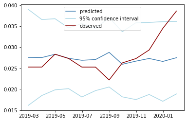

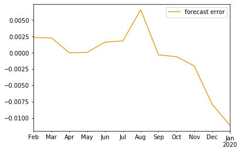

```
(forecast error   -0.000614
 dtype: float64, predicted    0.027297
 dtype: float64)
```

```python
#plotting
observed = pd.DataFrame(pd.read_csv(r'C:\Users\aasg\OneDrive\Escritorio\Tilburg University\Thesis\R_Files\dfCL.csv',
                       sep = ',',
                       skiprows = len(dataCL) - 12,
                       usecols = [2]))
observed.columns = ['observed']
observed.index = pd.date_range('02/01/2019',periods=12,freq='M')

plt.plot(mean_forecast, label = 'predicted', color = 'SteelBlue')
plt.plot(upper_bound, label = '95% confidence interval', color = 'lightblue')
plt.plot(lower_bound, color = 'lightblue')
plt.plot(observed, label = 'observed', color = 'DarkRed')
plt.legend()
plt.show

model_error = array(mean_forecast) - array(observed)
model_error = pd.DataFrame(model_error, index=pd.date_range('02/01/2019',periods=12,freq='M'))
model_error.columns = ['forecast error']

model_error.plot(color = 'goldenrod')
plt.show()

model_error.mean(), mean_forecast.mean()
```

```python
mean_forecast.to_csv(r'C:\Users\aasg\OneDrive\Escritorio\Tilburg University\Thesis\Python_Files\nn_keras_predicted_cl.csv')
model_error.to_csv(r'C:\Users\aasg\OneDrive\Escritorio\Tilburg University\Thesis\Python_Files\nn_keras_error_cl.csv')
```

In the case of Chile, the model makes a great prediction of future inflation within its 95% confidence interval for the most part, underestimating inflation 6 bps on average. In similar fashion, average inflation forecast is consistent with the Central Bank's target range of 2% to 4%.

## Neural Network for MX

```python
#training
#inputs raw
in_inf = array(dataMX.loc['2001-01-01':'2015-01-01', ['infMX']])
in_int = array(dataMX.loc['2001-01-01':'2015-01-01', ['intrateMX']])
in_M2  = array(dataMX.loc['2001-01-01':'2015-01-01', ['M2MX']])
in_gdp = array(dataMX.loc['2001-01-01':'2015-01-01', ['OutputGapMX']])
in_u   = array(dataMX.loc['2001-01-01':'2015-01-01', ['urateMX']])
in_rer = array(dataMX.loc['2001-01-01':'2015-01-01', ['RERMX']])
in_rw  = array(dataMX.loc['2001-01-01':'2015-01-01', ['realWMX']])


#output raw
out_inf = array(dataMX.loc['2001-01-01':'2015-01-01', ['infMX']])

#reshape to [rows, columns]
in_inf = in_inf.reshape((len(in_inf), 1))
in_int = in_int.reshape((len(in_int), 1))
in_M2  = in_M2.reshape((len(in_M2), 1))
in_gdp = in_gdp.reshape((len(in_gdp), 1))
in_u   = in_u.reshape((len(in_u), 1))
in_rer = in_rer.reshape((len(in_rer), 1))


out_inf = out_inf.reshape((len(out_inf), 1))


#validation
#inputs raw
valin_inf = array(dataMX.loc['2015-01-01':'2019-01-01', ['infMX']])
valin_int = array(dataMX.loc['2015-01-01':'2019-01-01', ['intrateMX']])
valin_M2  = array(dataMX.loc['2015-01-01':'2019-01-01', ['M2MX']])
valin_gdp = array(dataMX.loc['2015-01-01':'2019-01-01', ['OutputGapMX']])
valin_u   = array(dataMX.loc['2015-01-01':'2019-01-01', ['urateMX']])
valin_rer = array(dataMX.loc['2015-01-01':'2019-01-01', ['RERMX']])
valin_rw  = array(dataMX.loc['2015-01-01':'2019-01-01', ['realWMX']])

#output raw
valout_inf = array(dataMX.loc['2015-01-01':'2019-01-01', ['infMX']])

#reshape to [rows, columns]
valin_inf = valin_inf.reshape((len(valin_inf), 1))
valin_int = valin_int.reshape((len(valin_int), 1))
valin_M2  = valin_M2.reshape((len(valin_M2), 1))
valin_gdp = valin_gdp.reshape((len(valin_gdp), 1))
valin_u   = valin_u.reshape((len(valin_u), 1))
valin_rer = valin_rer.reshape((len(valin_rer), 1))


valout_inf = valout_inf.reshape((len(valout_inf), 1))

#out-of-sample inputs
x_inf = array(dataMX.loc['2018-02-01':'2019-01-01', ['infMX']])
x_int = array(dataMX.loc['2018-02-01':'2019-01-01', ['intrateMX']])
x_M2  = array(dataMX.loc['2018-02-01':'2019-01-01', ['M2MX']])
x_gdp = array(dataMX.loc['2018-02-01':'2019-01-01', ['OutputGapMX']])
x_u   = array(dataMX.loc['2018-02-01':'2019-01-01', ['urateMX']])
x_rer = array(dataMX.loc['2018-02-01':'2019-01-01', ['RERMX']])
x_rw  = array(dataMX.loc['2018-02-01':'2019-01-01', ['realWMX']])

#stack columns horizontally
dataset = hstack((in_inf, in_int, in_M2, in_gdp, in_u, in_rer, in_rw, out_inf))
valset = hstack((valin_inf, valin_int, valin_M2, valin_gdp, valin_u, valin_rer, valin_rw, valout_inf))

#timesteps
n_steps_in, n_steps_out = 12, 12 #use 12 observations to predict next 12

X, y = split_sequences(dataset, n_steps_in, n_steps_out)
print(X.shape, y.shape) #shape of input and output
valX, valy = split_sequences(valset, n_steps_in, n_steps_out)
```

```
(147, 12, 7) (147, 12)
```

```
<function matplotlib.pyplot.show(*args, **kw)>
```

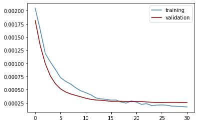

```python
n_features = X.shape[2]

#model

model = Sequential()
model.add(LSTM(100,
               activation = 'tanh',
               return_sequences = True,
               input_shape = (n_steps_in, n_features)))
model.add(LSTM(100,
               dropout = 0.8,
               recurrent_dropout = 0.8,
               activation = 'tanh'))
model.add(Dense(50, activation = 'tanh'))
model.add(Dense(25, activation = 'tanh'))
model.add(Dense(n_steps_out))

#compile model

model.compile(optimizer = keras.optimizers.Adam(learning_rate = 0.0001),
              loss = 'mse')


es = EarlyStopping(monitor = 'val_loss',
                  mode = 'min',
                  min_delta = 0.01,
                  patience = 30,
                  verbose = 0)

#fit
fit = model.fit(X,
          y,
          validation_data = (valX, valy),
          epochs = 500,
          verbose = 0,
          callbacks = [es])

#check for overfitting
plt.plot(fit.history['loss'], label = 'training', color = 'SteelBlue')
plt.plot(fit.history['val_loss'], label = 'validation', color = 'DarkRed')
plt.legend()
plt.show
```

```
[[0.03458778 0.03110803 0.03846157 0.03253454 0.03583873 0.03239229
  0.03407976 0.03598268 0.0401805  0.03601487 0.03502305 0.03735409]]
```

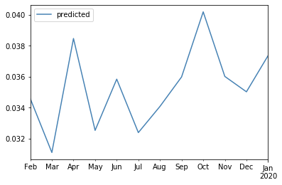

```python
#shape out-of-sample inputs
x_input = array([x_inf,
                 x_int,
                 x_M2,
                 x_gdp,
                 x_u,
                 x_rer,
                 x_rw])
x_input = x_input.reshape((1, n_steps_in, n_features))

yhat = model.predict(x_input, verbose = 0)
print(yhat)

predicted = pd.DataFrame(yhat.T, index=pd.date_range('02/01/2019',periods=12,freq='M'))
predicted.columns = ['predicted']

predicted.plot(color = 'SteelBlue')
plt.show()
```

```python
n = 50
results = []
for i in range(0, n):
    model = Sequential()
    model.add(LSTM(100,
               activation = 'tanh',
               return_sequences = True,
               input_shape = (n_steps_in, n_features)))
    model.add(LSTM(100,
               dropout = 0.8,
               recurrent_dropout = 0.8,
              activation = 'tanh'))
    model.add(Dense(50, activation = 'tanh'))
    model.add(Dense(25, activation = 'tanh'))
    model.add(Dense(n_steps_out))

    model.compile(optimizer = keras.optimizers.Adam(learning_rate = 0.0001),
              loss = 'mse')

    fit = model.fit(X,
          y,
          validation_data = (valX, valy),
          epochs = 500,
          verbose = 0,
          callbacks = [es])

    yhat = model.predict(x_input, verbose = 0)
    results.append((yhat))
```

```python
iter_output = pd.DataFrame(np.concatenate(results)) #build data frame with results
iter_output.columns = ['m1', 'm2', 'm3', 'm4', 'm5', 'm6', 'm7', 'm8', 'm9', 'm10', 'm11', 'm12']

#mean
mean_forecast = pd.DataFrame([iter_output['m1'].mean(),
                iter_output['m2'].mean(),
                iter_output['m3'].mean(),
                iter_output['m4'].mean(),
                iter_output['m5'].mean(),
                iter_output['m6'].mean(),
                iter_output['m7'].mean(),
                iter_output['m8'].mean(),
                iter_output['m9'].mean(),
                iter_output['m10'].mean(),
                iter_output['m11'].mean(),
                iter_output['m12'].mean()], index=pd.date_range('02/01/2019',periods=12,freq='M')) #mean dataframe
mean_forecast.columns = ['predicted']

#standard deviation
se_forecast = pd.DataFrame([iter_output['m1'].std(),
                iter_output['m2'].std(),
                iter_output['m3'].std(),
                iter_output['m4'].std(),
                iter_output['m5'].std(),
                iter_output['m6'].std(),
                iter_output['m7'].std(),
                iter_output['m8'].std(),
                iter_output['m9'].std(),
                iter_output['m10'].std(),
                iter_output['m11'].std(),
                iter_output['m12'].std()], index=pd.date_range('02/01/2019',periods=12,freq='M')) #se daaframe
se_forecast.columns = ['predicted']
```

```python
upper_bound = mean_forecast + 2*se_forecast
lower_bound = mean_forecast - 2*se_forecast
```

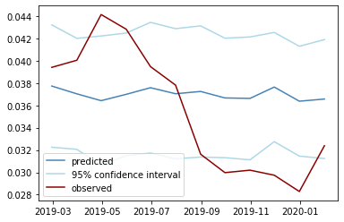

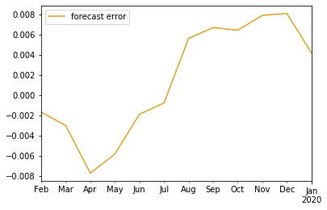

```
(forecast error    0.001501
 dtype: float64, predicted    0.036992
 dtype: float64)
```

```python
#plotting
observed = pd.DataFrame(pd.read_csv(r'C:\Users\aasg\OneDrive\Escritorio\Tilburg University\Thesis\R_Files\dfMX.csv',
                       sep = ',',
                       skiprows = len(dataMX) - 12,
                       usecols = [2]))
observed.columns = ['observed']
observed.index = pd.date_range('02/01/2019',periods=12,freq='M')

plt.plot(mean_forecast, label = 'predicted', color = 'SteelBlue')
plt.plot(upper_bound, label = '95% confidence interval', color = 'lightblue')
plt.plot(lower_bound, color = 'lightblue')
plt.plot(observed, label = 'observed', color = 'DarkRed')
plt.legend()
plt.show

model_error = array(mean_forecast) - array(observed)
model_error = pd.DataFrame(model_error, index=pd.date_range('02/01/2019',periods=12,freq='M'))
model_error.columns = ['forecast error']

model_error.plot(color = 'goldenrod')
plt.show()

model_error.mean(), mean_forecast.mean()
```

```python
mean_forecast.to_csv(r'C:\Users\aasg\OneDrive\Escritorio\Tilburg University\Thesis\Python_Files\nn_keras_predicted_mx.csv')
model_error.to_csv(r'C:\Users\aasg\OneDrive\Escritorio\Tilburg University\Thesis\Python_Files\nn_keras_error_mx.csv')
```

Although the model manages to predict most of future inflation within its 95% confidence interval, it overestimates mexican inflation from september until december of 2019. Additionally, on average it overestimates inflation by almost 15 bps and the on point forecast's mean falls close to the upper bound of Banco de Mexico's target inflation.